# Notebook

**Research Question:** "For variable coding (judgement ⑪), how accurately does each model fill the fixed 37-field schema — per-field, against Opus-coded gold — and which covariates are reliably codable at all?"

*Judgement ⑪ of 11 · Track B, step 2. The fields clustering runs on are only as good as this step. Numbers computed from the run.*

**Abstract.** Variable coding (judgement ⑪) fills the fixed **37-field** schema with values — the covariates clustering actually runs on. We score each of **22 models** on 30 posts against **Opus-coded gold**, per field, on presence (did it populate the field iff Opus did) and value agreement (overlap of the values). **gemini-3.5-flash** codes best (strict F1=0.37, counting a field correct only when it is both populated and its values overlap gold). But the sharper finding is per-field: some covariates are reliably codable — **clinical_trial_participation, conditions, biomarker_results** — while others are near- unusable no matter the model — **dosage, misdiagnosis, healthcare_system** — which tells clustering which axes to trust and which to drop.

## 1. What this judgement is, and why it's load-bearing

`llm_extract.py` reads a post and fills the fixed schema — `age`, `conditions`, `functional_status_tier`, `treatment_outcome`, and 33 others. These *are* the clustering covariates: a mis-coded or missing value is a corrupt or absent feature. Because the schema is fixed and the source text is given, this is factual — scored per field against an Opus-coded gold, on whether the model populates the right fields (presence) and gets the right values.

## 2. Correctness scorecard

Per model, three numbers: **presence F1** (did it populate the fields Opus did?), **value agreement** (when both populate a field, do the values overlap?), and **strict F1** (a field counts only if populated *and* values agree). Strict F1 is the headline — it penalises both missing a field and filling it with the wrong value.

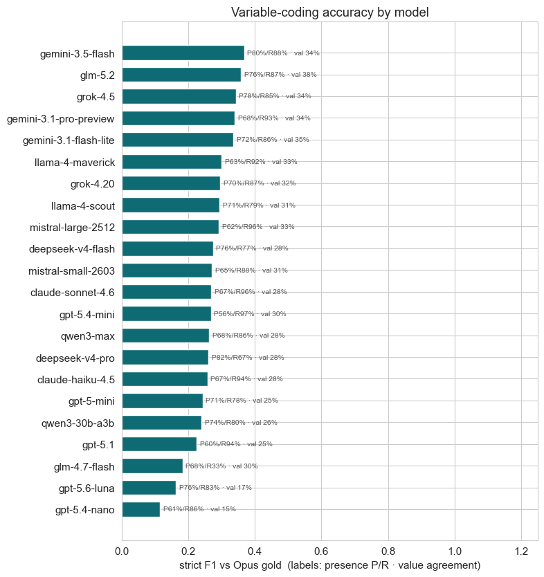

**Per-model coding accuracy**

| model | strict F1 | presence F1 | precision | recall | value agree | $/1M in |
| --- | --- | --- | --- | --- | --- | --- |
| gemini-3.5-flash | 0.37 | 0.84 | 80% | 88% | 34% | $1.5 |
| glm-5.2 | 0.36 | 0.81 | 76% | 87% | 38% | $0.955 |
| grok-4.5 | 0.34 | 0.81 | 78% | 85% | 34% | $2 |
| gemini-3.1-pro-preview | 0.34 | 0.78 | 68% | 93% | 34% | $2 |
| gemini-3.1-flash-lite | 0.33 | 0.78 | 72% | 86% | 35% | $0.25 |
| llama-4-maverick | 0.30 | 0.75 | 63% | 92% | 33% | $0.2 |
| grok-4.20 | 0.30 | 0.77 | 70% | 87% | 32% | $1.25 |
| llama-4-scout | 0.29 | 0.75 | 71% | 79% | 31% | $0.1 |
| mistral-large-2512 | 0.29 | 0.75 | 62% | 96% | 33% | $0.5 |
| deepseek-v4-flash | 0.27 | 0.77 | 76% | 77% | 28% | $0.098 |
| mistral-small-2603 | 0.27 | 0.74 | 65% | 88% | 31% | $0.15 |
| claude-sonnet-4.6 | 0.27 | 0.79 | 67% | 96% | 28% | $3 |
| gpt-5.4-mini | 0.27 | 0.71 | 56% | 97% | 30% | $0.75 |
| qwen3-max | 0.26 | 0.76 | 68% | 86% | 28% | $0.78 |
| deepseek-v4-pro | 0.26 | 0.74 | 82% | 67% | 28% | $0.435 |
| claude-haiku-4.5 | 0.26 | 0.78 | 67% | 94% | 28% | $1 |
| gpt-5-mini | 0.24 | 0.74 | 71% | 78% | 25% | $0.25 |
| qwen3-30b-a3b | 0.24 | 0.77 | 74% | 80% | 26% | $0.13 |
| gpt-5.1 | 0.23 | 0.74 | 60% | 94% | 25% | $1.25 |
| glm-4.7-flash | 0.18 | 0.44 | 68% | 33% | 30% | $0.061 |
| gpt-5.6-luna | 0.16 | 0.80 | 76% | 83% | 17% | $1 |
| gpt-5.4-nano | 0.12 | 0.71 | 61% | 86% | 15% | $0.2 |

## 3. The real finding — which covariates are codable

Model choice matters less than *field* choice. Pooled across the roster, each field has its own codability: some are extracted reliably, others fail for everyone. A field no model can code is a clustering axis to drop, regardless of which model runs production.

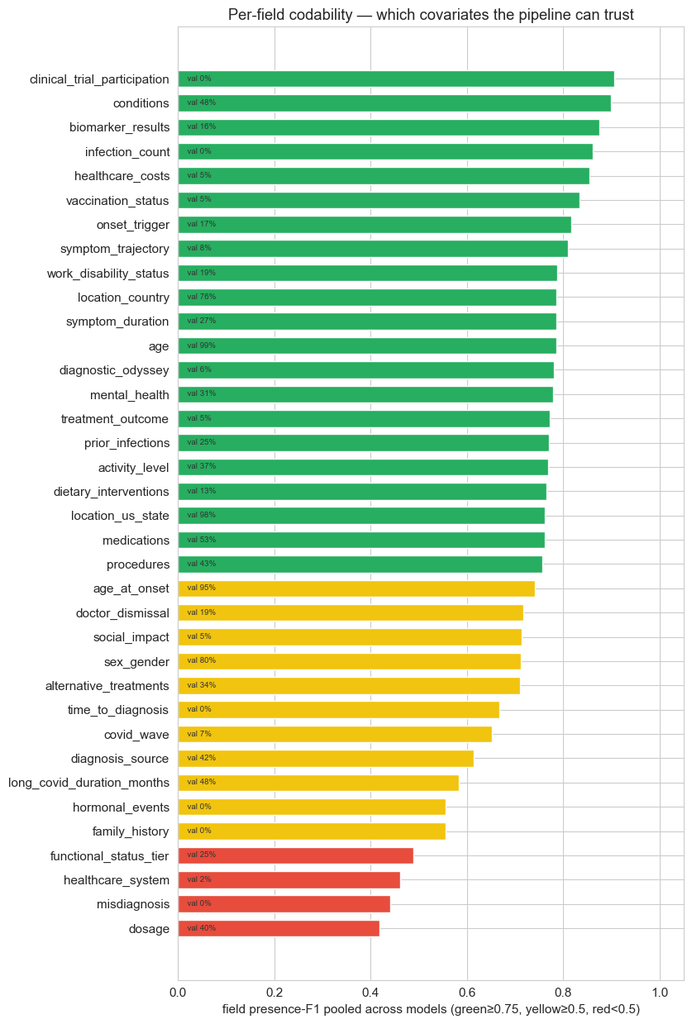

**What this shows:** of 37 schema fields, **21** are coded reliably (F1≥0.75) and **4** are near-unusable (F1<0.5) — e.g. dosage, misdiagnosis, healthcare_system, functional_status_tier. And presence is the easy part: even on fields both populate, mean value agreement is only **29%**, so the *values* drift further than the field-presence numbers suggest.

## 4. Counterintuitive: presence is easy, values are hard — and models split eager vs cautious

A model can populate the right fields yet fill them with subtly wrong values, so the presence numbers flatter the real accuracy. And as in drug-ID, models sit on a precision–recall tradeoff — some over-populate (fill fields Opus left null), some under-populate (miss fields Opus found).

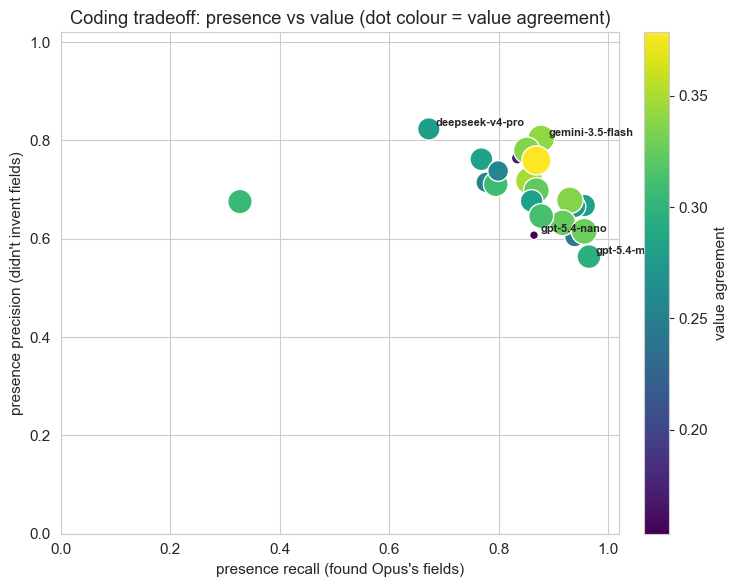

**What this shows:** the most thorough is **gpt-5.4-mini** (97% recall), the most conservative **deepseek-v4-pro** (82% precision). But note the colour: even top presence models carry value agreement around 30% — populating the field is not the same as coding it right, and clustering consumes the *value*, not the presence.

## 5. Conclusion & scorecard — coding accuracy per dollar

The scorecard, and the design's payoff for the covariate step.

**⑪ coding — full scorecard**

| model | strict F1 | presence F1 | value agree | precision | recall | $/1M in |
| --- | --- | --- | --- | --- | --- | --- |
| gemini-3.5-flash | 0.37 | 0.84 | 34% | 80% | 88% | $1.5 |
| glm-5.2 | 0.36 | 0.81 | 38% | 76% | 87% | $0.955 |
| grok-4.5 | 0.34 | 0.81 | 34% | 78% | 85% | $2 |
| gemini-3.1-pro-preview | 0.34 | 0.78 | 34% | 68% | 93% | $2 |
| gemini-3.1-flash-lite | 0.33 | 0.78 | 35% | 72% | 86% | $0.25 |
| llama-4-maverick | 0.30 | 0.75 | 33% | 63% | 92% | $0.2 |
| grok-4.20 | 0.30 | 0.77 | 32% | 70% | 87% | $1.25 |
| llama-4-scout | 0.29 | 0.75 | 31% | 71% | 79% | $0.1 |
| mistral-large-2512 | 0.29 | 0.75 | 33% | 62% | 96% | $0.5 |
| deepseek-v4-flash | 0.27 | 0.77 | 28% | 76% | 77% | $0.098 |
| mistral-small-2603 | 0.27 | 0.74 | 31% | 65% | 88% | $0.15 |
| claude-sonnet-4.6 | 0.27 | 0.79 | 28% | 67% | 96% | $3 |
| gpt-5.4-mini | 0.27 | 0.71 | 30% | 56% | 97% | $0.75 |
| qwen3-max | 0.26 | 0.76 | 28% | 68% | 86% | $0.78 |
| deepseek-v4-pro | 0.26 | 0.74 | 28% | 82% | 67% | $0.435 |
| claude-haiku-4.5 | 0.26 | 0.78 | 28% | 67% | 94% | $1 |
| gpt-5-mini | 0.24 | 0.74 | 25% | 71% | 78% | $0.25 |
| qwen3-30b-a3b | 0.24 | 0.77 | 26% | 74% | 80% | $0.13 |
| gpt-5.1 | 0.23 | 0.74 | 25% | 60% | 94% | $1.25 |
| glm-4.7-flash | 0.18 | 0.44 | 30% | 68% | 33% | $0.061 |
| gpt-5.6-luna | 0.16 | 0.80 | 17% | 76% | 83% | $1 |
| gpt-5.4-nano | 0.12 | 0.71 | 15% | 61% | 86% | $0.2 |

Verdict

- **Best coder:** gemini-3.5-flash (strict F1 0.37).

- **Best value:** **gemini-3.1-flash-lite** — strict F1 0.33 at $0.25/1M input, within 5 points of the best while cheaper.

- **Trust the field, not just the model:** 21 of 37 covariates code reliably (F1≥0.75); 4 are near-unusable (F1<0.5) and should be dropped or hand-audited before clustering. Measured on presence-F1 **pooled across models**, so it is a property of the field rather than a per-model ranking — it does not establish that every individual model fails them.

- **Values drift more than presence** (mean value agreement 29%), so even a good presence-F1 needs the value check before a covariate is trusted.

## 6. Research limitations

- **Opus-as-gold is silver.** It codes the reference values, so a systematic Opus blind spot (a field it mis-reads, a value convention it prefers) becomes invisible "truth". The GT-review step (a second frontier coder) would tighten this — deferred.
- **Value matching is set-overlap (Jaccard).** "long covid" vs "long-covid" match after normalization, but paraphrases ("housebound" vs "cannot leave the house") do not — so value agreement is a lower bound; a semantic judge would score some near-misses as correct.
- **Presence vs value.** A field Opus left null that a model fills is scored a hallucination, but occasionally the model is right and Opus missed it (the mirror of ②); without the GT-review we can't separate those.
- **Posts** are 30 long-COVID posts; per-field codability is schema- and corpus-specific.
- **Price** is input $/1M and ignores the (larger) output token cost of coding 37 fields — an order-of-magnitude signal.
- Measures the correctness of a measurement step, not any treatment effect.

**Provenance**

| item | value |
| --- | --- |
| run generated (UTC) | 2026-07-18T01:25:02.290564+00:00 |
| judgement | 11_variable_coding |
| candidate models | 22 (22 produced codings) |
| gold (truth) | anthropic/claude-opus-4.8 |
| schema | covidlonghaulers_v1 |
| posts / fields | 30 / 37 |
| temperature | 0.0 |
| skill version | research-assistant v2 |

These findings reflect the behaviour of a measurement pipeline and model knowledge, not population-level treatment effects. This is not medical advice.